# Sorites Data Summary

Erin Bennett

# Experiments

## Wording used in sorites experiments

Sorites variations

| id | date | inductive phrasing | N |
| --- | --- | --- | --- |
| 00 | 2013 August 27 7am | relative | 30 |
| 01 | 2013 August 28 12pm | relative | 50 |
| 07a | 2014 January 31 7am | both* | 10 |
| 07b | 2014 February 5 5am | both* | 60 |
| 07c | 2014 February 6 5am | both | 50 |
| 10 | 2015 April 23 4am | conditional | 30 |
| 11 | 2015 June 5 2pm | relative | 30 |

Possible phrasings of inductive premise:

- relative: “An ITEM that costs $EPS less than an expensive ITEM is also expensive.”
- conditional: “If an ITEM is expensive, then another ITEM that costs $EPS less is also expensive.”

Consistent across all experiments:

- Concrete premise: “An ITEM that costs $VAL is expensive.”
- Prompt: “Please indicate how much you agree with the above statement.”
- Left (lower) label of likert scale: “Completely disagree”"
- Right (higher) label of likert scale: “Completely agree”"

*In experiments 7a and 7b, phrasing was randomized between participants (either relative or conditional), but I did not record which phrasing was used for which participant

## Results of sorites experiments

### Range of values

Results from experiments with similar ranges are more similar to each other than to results from experiments with different ranges. But it’s not clear to me why.

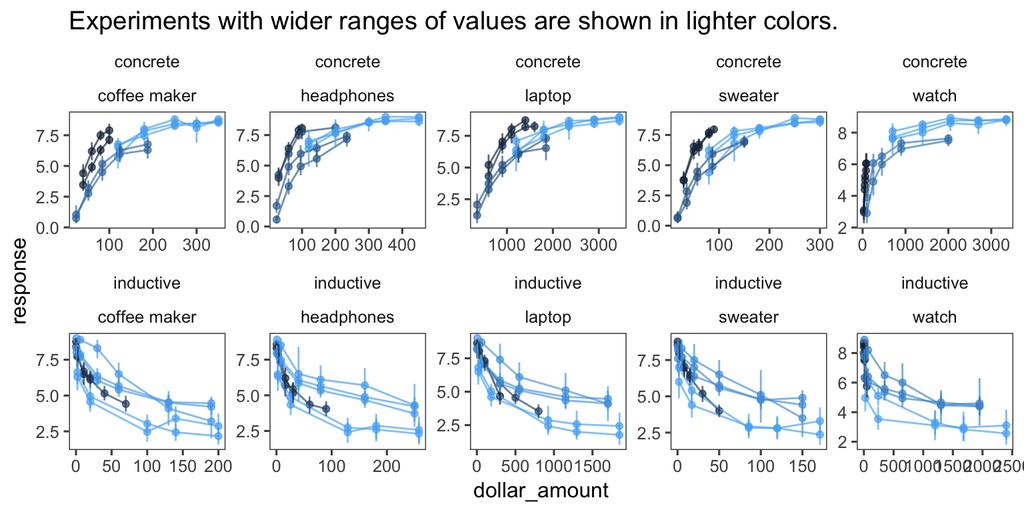

### Inductive premise phrasing

There were two phrasings, “relative clause” and “conditional.” They tend to get similar endorsements.

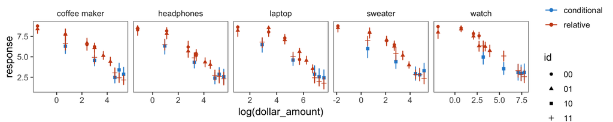

## Priors experiments

Here are the instructions participants got in all of the prior experiments:

> In each scenario, someone has just bought an item. Please give your best estimate of the price of the item. You will do this by rating how likely you think it is that the actual price is within each of NBINS different ranges.

> NAME bought a new *ITEM*.

> Please rate how likely it is that the cost of the *ITEM* is within each of the following ranges.

There was a “split” condition (10 participants), where participants saw one bin at a time. In all other versions, the sliders for each item were shown together. We did not collect enough data in the split condition to normalize responses.

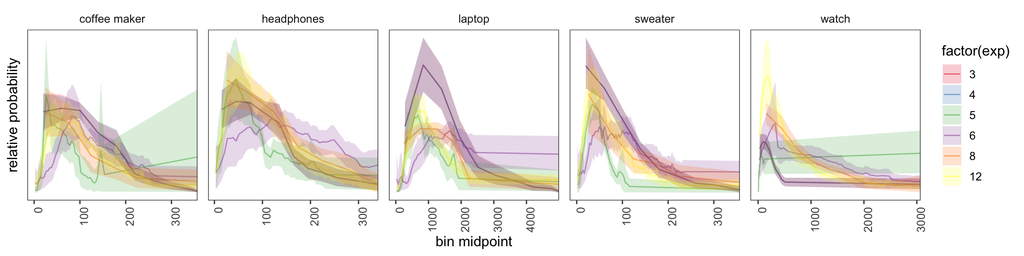